# Storm Data Analysis

## Data processing 3: Extract valid grouped EVTYPE entries

```r
tempStormData <- newStormData
finalStormData <-subset(tempStormData, EVTYPE=="COLD/WIND CHILL")
tempStormData <-subset(tempStormData, EVTYPE!="COLD/WIND CHILL")
finalStormData <-rbind(finalStormData, subset(tempStormData,
                        EVTYPE=="EXTREME COLD/WIND CHILL"))
tempStormData <-subset(tempStormData,
                       EVTYPE!="EXTREME COLD/WIND CHILL")
finalStormData <-rbind(finalStormData, subset(tempStormData,
                        EVTYPE=="FROST/FREEZE"))
tempStormData <-subset(tempStormData,EVTYPE!="FROST/FREEZE")
finalStormData <-rbind(finalStormData, subset(tempStormData,
                        EVTYPE=="HURRICANE/TYPHOON"))
tempStormData <-subset(tempStormData,EVTYPE!="HURRICANE/TYPHOON")
finalStormData <-rbind(finalStormData, subset(tempStormData,
                        EVTYPE=="MARINE HURRICANE/TYPHOON"))
tempStormData <-subset(tempStormData,
                       EVTYPE!="MARINE HURRICANE/TYPHOON")
finalStormData <-rbind(finalStormData, subset(tempStormData,
                        EVTYPE=="STORM SURGE/TIDE"))
tempStormData <-subset(tempStormData,
                       EVTYPE!="STORM SURGE/TIDE")
finalStormData <-rbind(finalStormData, subset(tempStormData,
                        EVTYPE=="LAKE-EFFECT SNOW"))
tempStormData <-subset(tempStormData,
                       EVTYPE!="LAKE-EFFECT SNOW")
```

## Data processing 4: EVTYPE again

- correcting grouped entries not using “/”

```r
tempStormData$EVTYPE <- gsub("DEBRIS FLOW FLOOD",
                             "DEBRIS FLOW/FLOOD",
                             tempStormData$EVTYPE)
tempStormData$EVTYPE <- gsub("DROUGHT THUNDERSTORM WIND",
                             "DROUGHT/THUNDERSTORM WIND",
                             tempStormData$EVTYPE)
tempStormData$EVTYPE <- gsub("DUST DEVIL WATERSPOUT",
                             "DUST DEVIL/WATERSPOUT",
                             tempStormData$EVTYPE)
tempStormData$EVTYPE <- gsub("FLASH FLOOD DEBRIS FLOW",
                             "FLASH FLOOD/DEBRIS FLOW",
                             tempStormData$EVTYPE)
tempStormData$EVTYPE <- gsub("FLASH FLOOD WIND",
                             "FLASH FLOOD/STRONG WIND",
                             tempStormData$EVTYPE)
tempStormData$EVTYPE <- gsub("FLASH FLOOD - HEAVY RAIN",
                             "FLASH FLOOD/HEAVY RAIN",
                             tempStormData$EVTYPE)
tempStormData$EVTYPE <- gsub("FLOOD & HEAVY RAIN",
                             "FLOOD/HEAVY RAIN",
                             tempStormData$EVTYPE)
tempStormData$EVTYPE <- gsub("^FLOOD/FLASH$",
                             "FLOOD/FLASH FLOOD",
                             tempStormData$EVTYPE)
tempStormData$EVTYPE <- gsub("FLOOD/FLASH/FLOOD",
                             "FLOOD/FLASH FLOOD",
                             tempStormData$EVTYPE)
tempStormData$EVTYPE <- gsub("HEAT DROUGHT",
                             "HEAT/DROUGHT",
                             tempStormData$EVTYPE)
tempStormData$EVTYPE <- gsub("HEAT AND DROUGHT",
                             "HEAT/DROUGHT",
                             tempStormData$EVTYPE)
tempStormData$EVTYPE <- gsub("HEAVY RAIN AND FLOOD",
                             "HEAVY RAIN/FLOOD",
                             tempStormData$EVTYPE)
tempStormData$EVTYPE <- gsub("HEAVY SURF COASTAL FLOOD",
                             "HIGH SURF/COASTAL FLOOD",
                             tempStormData$EVTYPE)
tempStormData$EVTYPE <- gsub("HIGH SURF COASTAL FLOOD",
                             "HIGH SURF/COASTAL FLOOD",
                             tempStormData$EVTYPE)
tempStormData$EVTYPE <- gsub("HIGH WIND HEAVY RAIN",
                             "HIGH WIND/HEAVY RAIN",
                             tempStormData$EVTYPE)
tempStormData$EVTYPE <- gsub("SNOW AND ICE STORM",
                             "HEAVY SNOW/ICE STORM",
                             tempStormData$EVTYPE)
tempStormData$EVTYPE <- gsub("HEAVY SNOW AND HIGH WIND",
                             "HEAVY SNOW/HIGH WIND",
                             tempStormData$EVTYPE)
tempStormData$EVTYPE <- gsub("HEAVY SNOW AND FLOOD",
                             "HEAVY SNOW/FLOOD",
                             tempStormData$EVTYPE)
tempStormData$EVTYPE <- gsub("HEAVY SNOW AND STRONG WIND",
                             "HEAVY SNOW/STRONG WIND",
                             tempStormData$EVTYPE)
tempStormData$EVTYPE <- gsub("LIGHTNING AND HEAVY RAIN",
                             "LIGHTNING/HEAVY RAIN",
                             tempStormData$EVTYPE)
tempStormData$EVTYPE <- gsub("LIGHTNING FIRE",
                             "LIGHTNING/WILDFIRE",
                             tempStormData$EVTYPE)
tempStormData$EVTYPE <- gsub("LIGHTNING AND THUNDERSTORM WIND",
                             "LIGHTNING/THUNDERSTORM WIND",
                             tempStormData$EVTYPE)
tempStormData$EVTYPE <- gsub("LIGHTNING THUNDERSTORM WIND",
                             "LIGHTNING/THUNDERSTORM WIND",
                             tempStormData$EVTYPE)
tempStormData$EVTYPE <- gsub("SLEET/SNOW","SLEET/HEAVY SNOW",
                             tempStormData$EVTYPE)
tempStormData$EVTYPE <- gsub("^SNOW/SLEET/SLEET", "HEAVY SNOW/SLEET",
                             tempStormData$EVTYPE)
tempStormData$EVTYPE <- gsub("^SNOW/SLEET", "HEAVY SNOW/SLEET",
                             tempStormData$EVTYPE)
tempStormData$EVTYPE <- gsub("SNOW AND HEAVY SNOW", "HEAVY SNOW",
                             tempStormData$EVTYPE)
tempStormData$EVTYPE <- gsub("HEAVY SNOW SQUALLS",
                             "HEAVY SNOW/WINTER WEATHER",
                             tempStormData$EVTYPE)
tempStormData$EVTYPE <- gsub("HEAVY SNOW/SQUALLS",
                             "HEAVY SNOW/WINTER WEATHER",
                             tempStormData$EVTYPE)
tempStormData$EVTYPE <- gsub("HEAVY SNOW-SQUALLS",
                             "HEAVY SNOW/WINTER WEATHER",
                             tempStormData$EVTYPE)
tempStormData$EVTYPE <- gsub("THUNDERSTORM WIND HAIL",
                             "THUNDERSTORM WIND/HAIL",
                             tempStormData$EVTYPE)
tempStormData$EVTYPE <- gsub("THUNDERSTORM WINDHAIL",
                             "THUNDERSTORM WIND/HAIL",
                             tempStormData$EVTYPE)
tempStormData$EVTYPE <- gsub("THUNDERSTORM WIND LIGHTNING",
                             "THUNDERSTORM WIND/LIGHTNING",
                             tempStormData$EVTYPE)
tempStormData$EVTYPE <- gsub("TORNADO, THUNDERSTORM WIND, HAIL",
                             "TORNADO/THUNDERSTORM WIND/HAIL",
                             tempStormData$EVTYPE)
tempStormData$EVTYPE <- gsub("WATERSPOUT TORNADO",
                             "WATERSPOUT/TORNADO",
                             tempStormData$EVTYPE)
tempStormData$EVTYPE <- gsub("WATERSPOUT-TORNADO",
                             "WATERSPOUT/TORNADO",
                             tempStormData$EVTYPE)
tempStormData$EVTYPE <- gsub("WINTER STORM HIGH WIND",
                             "WINTER STORM/HIGH WIND",
                             tempStormData$EVTYPE)
```

## Data processing 5: EVTYPE

- split all remaining entries with /

```r
tempStormData <- separate_rows(tempStormData, EVTYPE, sep="/")
tempStormData$EVTYPE <- str_trim(tempStormData$EVTYPE, "both")
```

## Data processing 6: EVTYPE

-Correct additional data by simplication to match standard

```r
tempStormData$EVTYPE <- gsub("^HAIL .*$",
                             "HAIL",
                             tempStormData$EVTYPE)
tempStormData$EVTYPE <- gsub("^HIGH WIND .*$",
                             "HIGH WIND",
                             tempStormData$EVTYPE)
tempStormData$EVTYPE <- gsub("^HURRICANE .*$",
                             "HURRICANE/TYPHOON",
                             tempStormData$EVTYPE)
tempStormData$EVTYPE <- gsub("^THUNDERSTORM WINDS .*$",
                             "THUNDERSTORM WIND",
                             tempStormData$EVTYPE)
tempStormData$EVTYPE <- gsub("^THUNDERSTORM WINDS.*$",
                             "THUNDERSTORM WIND",
                             tempStormData$EVTYPE)
tempStormData$EVTYPE <- gsub("^THUNDERSTORM WIND .*$",
                             "THUNDERSTORM WIND",
                             tempStormData$EVTYPE)
tempStormData$EVTYPE <- gsub("^THUNDERSTORM WIND.*$",
                             "THUNDERSTORM WIND",
                             tempStormData$EVTYPE)
tempStormData$EVTYPE <- gsub("^TORNADO .*$",
                             "TORNADO",
                             tempStormData$EVTYPE)
tempStormData$EVTYPE <- gsub("^TROPICAL STORM .*$",
                             "TROPICAL STORM",
                             tempStormData$EVTYPE)
```

## Data processing 7: EVTYPE

- transferring valid EVTYPE entries from tempStormData to finalStormData

```r
finalStormData <-rbind(finalStormData, subset(tempStormData,EVTYPE=="ASTRONOMICAL LOW TIDE"))
tempStormData <-subset(tempStormData,EVTYPE!="ASTRONOMICAL LOW TIDE")
finalStormData <-rbind(finalStormData, subset(tempStormData,EVTYPE=="AVALANCHE"))
tempStormData <-subset(tempStormData,EVTYPE!="AVALANCHE")
finalStormData <-rbind(finalStormData, subset(tempStormData,EVTYPE=="BLIZZARD"))
tempStormData <-subset(tempStormData,EVTYPE!="BLIZZARD")
finalStormData <-rbind(finalStormData, subset(tempStormData,EVTYPE=="COASTAL FLOOD"))
tempStormData <-subset(tempStormData,EVTYPE!="COASTAL FLOOD")
finalStormData <-rbind(finalStormData, subset(tempStormData,EVTYPE=="DEBRIS FLOW"))
tempStormData <-subset(tempStormData,EVTYPE!="DEBRIS FLOW")
finalStormData <-rbind(finalStormData, subset(tempStormData,EVTYPE=="DENSE FOG"))
tempStormData <-subset(tempStormData,EVTYPE!="DENSE FOG")
finalStormData <-rbind(finalStormData, subset(tempStormData,EVTYPE=="DENSE SMOKE"))
tempStormData <-subset(tempStormData,EVTYPE!="DENSE SMOKE")
finalStormData <-rbind(finalStormData, subset(tempStormData,EVTYPE=="DROUGHT"))
tempStormData <-subset(tempStormData,EVTYPE!="DROUGHT")
finalStormData <-rbind(finalStormData, subset(tempStormData,EVTYPE=="DUST DEVIL"))
tempStormData <-subset(tempStormData,EVTYPE!="DUST DEVIL")
finalStormData <-rbind(finalStormData, subset(tempStormData,EVTYPE=="DUST STORM"))
tempStormData <-subset(tempStormData,EVTYPE!="DUST STORM")
finalStormData <-rbind(finalStormData, subset(tempStormData,EVTYPE=="EXCESSIVE HEAT"))
tempStormData <-subset(tempStormData,EVTYPE!="EXCESSIVE HEAT")
finalStormData <-rbind(finalStormData, subset(tempStormData,EVTYPE=="FLASH FLOOD"))
tempStormData <-subset(tempStormData,EVTYPE!="FLASH FLOOD")
finalStormData <-rbind(finalStormData, subset(tempStormData,EVTYPE=="FLOOD"))
tempStormData <-subset(tempStormData,EVTYPE!="FLOOD")
finalStormData <-rbind(finalStormData, subset(tempStormData,EVTYPE=="FREEZING FOG"))
tempStormData <-subset(tempStormData,EVTYPE!="FREEZING FOG")
finalStormData <-rbind(finalStormData, subset(tempStormData,EVTYPE=="FUNNEL CLOUD"))
tempStormData <-subset(tempStormData,EVTYPE!="FUNNEL CLOUD")
finalStormData <-rbind(finalStormData, subset(tempStormData,EVTYPE=="HAIL"))
tempStormData <-subset(tempStormData,EVTYPE!="HAIL")
finalStormData <-rbind(finalStormData, subset(tempStormData,EVTYPE=="HEAT"))
tempStormData <-subset(tempStormData,EVTYPE!="HEAT")
finalStormData <-rbind(finalStormData, subset(tempStormData,EVTYPE=="HEAVY RAIN"))
tempStormData <-subset(tempStormData,EVTYPE!="HEAVY RAIN")
finalStormData <-rbind(finalStormData, subset(tempStormData,EVTYPE=="HEAVY SNOW"))
tempStormData <-subset(tempStormData,EVTYPE!="HEAVY SNOW")
finalStormData <-rbind(finalStormData, subset(tempStormData,EVTYPE=="HIGH SURF"))
tempStormData <-subset(tempStormData,EVTYPE!="HIGH SURF")
finalStormData <-rbind(finalStormData, subset(tempStormData,EVTYPE=="HIGH WIND"))
tempStormData <-subset(tempStormData,EVTYPE!="HIGH WIND")
finalStormData <-rbind(finalStormData, subset(tempStormData,
                        EVTYPE=="HURRICANE/TYPHOON"))
tempStormData <-subset(tempStormData,EVTYPE!="HURRICANE/TYPHOON")
finalStormData <-rbind(finalStormData, subset(tempStormData,EVTYPE=="ICE STORM"))
tempStormData <-subset(tempStormData,EVTYPE!="ICE STORM")
finalStormData <-rbind(finalStormData, subset(tempStormData,EVTYPE=="LAKESHORE FLOOD"))
tempStormData <-subset(tempStormData,EVTYPE!="LAKESHORE FLOOD")
finalStormData <-rbind(finalStormData, subset(tempStormData,EVTYPE=="LIGHTNING"))
tempStormData <-subset(tempStormData,EVTYPE!="LIGHTNING")
finalStormData <-rbind(finalStormData, subset(tempStormData,EVTYPE=="MARINE DENSE FOG"))
tempStormData <-subset(tempStormData,EVTYPE!="MARINE DENSE FOG")
finalStormData <-rbind(finalStormData, subset(tempStormData,EVTYPE=="MARINE HAIL"))
tempStormData <-subset(tempStormData,EVTYPE!="MARINE HAIL")
finalStormData <-rbind(finalStormData, subset(tempStormData,EVTYPE=="MARINE HEAVY FREEZING SPRAY"))
tempStormData <-subset(tempStormData,EVTYPE!="MARINE HEAVY FREEZING SPRAY")
finalStormData <-rbind(finalStormData, subset(tempStormData,EVTYPE=="MARINE HIGH WIND"))
tempStormData <-subset(tempStormData,EVTYPE!="MARINE HIGH WIND")
finalStormData <-rbind(finalStormData, subset(tempStormData,EVTYPE=="MARINE LIGHTNING"))
tempStormData <-subset(tempStormData,EVTYPE!="MARINE LIGHTNING")
finalStormData <-rbind(finalStormData, subset(tempStormData,EVTYPE=="MARINE STRONG WIND"))
tempStormData <-subset(tempStormData,EVTYPE!="MARINE STRONG WIND")
finalStormData <-rbind(finalStormData, subset(tempStormData,EVTYPE=="MARINE THUNDERSTORM WIND"))
tempStormData <-subset(tempStormData,EVTYPE!="MARINE THUNDERSTORM WIND")
finalStormData <-rbind(finalStormData, subset(tempStormData,EVTYPE=="MARINE TROPICAL DEPRESSION"))
tempStormData <-subset(tempStormData,EVTYPE!="MARINE TROPICAL DEPRESSION")
finalStormData <-rbind(finalStormData, subset(tempStormData,EVTYPE=="MARINE TROPICAL STORM"))
tempStormData <-subset(tempStormData,EVTYPE!="MARINE TROPICAL STORM")
finalStormData <-rbind(finalStormData, subset(tempStormData,EVTYPE=="RIP CURRENT"))
tempStormData <-subset(tempStormData,EVTYPE!="RIP CURRENT")
finalStormData <-rbind(finalStormData, subset(tempStormData,EVTYPE=="SEICHE"))
tempStormData <-subset(tempStormData,EVTYPE!="SEICHE")
finalStormData <-rbind(finalStormData, subset(tempStormData,EVTYPE=="SLEET"))
tempStormData <-subset(tempStormData,EVTYPE!="SLEET")
finalStormData <-rbind(finalStormData, subset(tempStormData,EVTYPE=="SNEAKER WAVE"))
tempStormData <-subset(tempStormData,EVTYPE!="SNEAKER WAVE")
finalStormData <-rbind(finalStormData, subset(tempStormData,EVTYPE=="STRONG WIND"))
tempStormData <-subset(tempStormData,EVTYPE!="STRONG WIND")
finalStormData <-rbind(finalStormData, subset(tempStormData,EVTYPE=="THUNDERSTORM WIND"))
tempStormData <-subset(tempStormData,EVTYPE!="THUNDERSTORM WIND")
finalStormData <-rbind(finalStormData, subset(tempStormData,EVTYPE=="TORNADO"))
tempStormData <-subset(tempStormData,EVTYPE!="TORNADO")
finalStormData <-rbind(finalStormData, subset(tempStormData,EVTYPE=="TROPICAL DEPRESSION"))
tempStormData <-subset(tempStormData,EVTYPE!="TROPICAL DEPRESSION")
finalStormData <-rbind(finalStormData, subset(tempStormData,EVTYPE=="TROPICAL STORM"))
tempStormData <-subset(tempStormData,EVTYPE!="TROPICAL STORM")
finalStormData <-rbind(finalStormData, subset(tempStormData,EVTYPE=="TSUNAMI"))
tempStormData <-subset(tempStormData,EVTYPE!="TSUNAMI")
finalStormData <-rbind(finalStormData, subset(tempStormData,EVTYPE=="VOLCANIC ASH"))
tempStormData <-subset(tempStormData,EVTYPE!="VOLCANIC ASH")
finalStormData <-rbind(finalStormData, subset(tempStormData,EVTYPE=="WATERSPOUT"))
tempStormData <-subset(tempStormData,EVTYPE!="WATERSPOUT")
finalStormData <-rbind(finalStormData, subset(tempStormData,EVTYPE=="WILDFIRE"))
tempStormData <-subset(tempStormData,EVTYPE!="WILDFIRE")
finalStormData <-rbind(finalStormData, subset(tempStormData,EVTYPE=="WINTER STORM"))
tempStormData <-subset(tempStormData,EVTYPE!="WINTER STORM")
finalStormData <-rbind(finalStormData, subset(tempStormData,EVTYPE=="WINTER WEATHER"))
tempStormData <-subset(tempStormData,EVTYPE!="WINTER WEATHER")
```

We disregard the leftover EVTYPES due to their ambiguity. Please see APPENDIX A.

## Data analysis 1: Preparing the summations

```r
dataFatalities <- finalStormData %>% group_by(EVTYPE) %>%
                    summarize(total=sum(FATALITIES)) %>%
                    arrange(desc(total)) %>% head(5)
dataInjuries <- finalStormData %>% group_by(EVTYPE) %>%
                    summarize(total=sum(INJURIES)) %>%
                     arrange(desc(total)) %>% head(5)
dataHarm <- finalStormData %>% group_by(EVTYPE) %>%
                    summarize(total=sum(totalHarm)) %>%
                    arrange(desc(total)) %>% head(5)
dataDMG <- finalStormData %>% group_by(EVTYPE) %>%
                    summarize(total=sum(totalDMG)) %>%
                    arrange(desc(total)) %>% head(5)
dataFatalities$GROUP <- "Fatalities"
dataInjuries$GROUP <- "Injuries"
dataHarm$GROUP <- "Total Harm"
dataHarm <- rbind(dataHarm, dataFatalities)
dataHarm <- rbind(dataHarm, dataInjuries)
```

## Data analysis 2: Graphing Harm

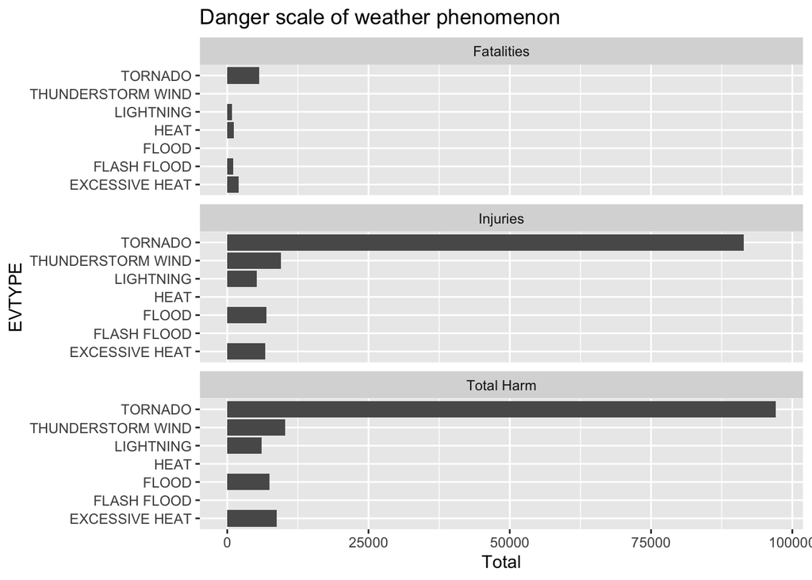

```r
g <- ggplot(data=dataHarm, aes(x=total, y=EVTYPE, group=GROUP))
g + geom_bar(stat="identity") + facet_wrap(~GROUP, nrow=3) + labs(title="Danger scale of weather phenomenon", x="Total")
```

- We can see from the chart that the EVTYPE that causes the most harm is the tornado.

## Data analysis 3: Graphing DMG

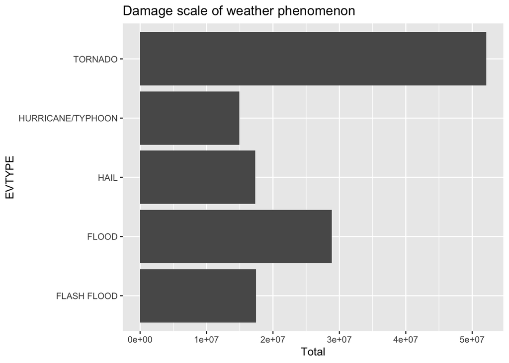

```r
g2 <- ggplot(data=dataDMG, aes(x=total, y=EVTYPE))
g2 + geom_bar(stat="identity") + labs(title="Damage scale of weather phenomenon", x="Total")
```

- We can see from the chart that the EVTYPE that causes the most damage is the tornado.

## Results

- The EVTYPE that causes the most injuries, deaths and both combined is the **tornado**.
- The EVTYPE that causes the most damage is also the **tornado**.

## APPENDIX A – Ambiguous EVTYPES that were discarded

- APACHE COUNTY
- ASTRONOMICAL HIGH TIDE
- AWNING
- BEACH EROSION
- BLOWING SNOW
- COASTAL EROSION
- COLD AND WER
- COLD AND WET CONDITIONS
- DROWNING
- EROSION
- EXCESSIVE WETNESS
- FALLING SNOW
- GRADIENT WIND
- HAZARDOUS SURF
- HEAVY SEAS
- HIGH
- HIGH SEAS
- HIGH WAVES
- ICE
- ICE FLOES
- LATE SEASON SNOW
- LIGHT SNOW
- LIGHT SNOWFALL
- MARINE ACCIDENT
- MARINE MISHAP
- MIXED PRECIPITATION
- MIXED PRECIP
- NON-SEVERE WIND DAMAGE
- NON-THUNDERSTORM WIND
- NON THUNDERSTORM WIND
- OTHER
- RAIN
- RAINTORM
- ROGUE WAVE
- ROUGH SEAS
- ROUGH SURF
- SEVERE TURBULENCE
- SEVERE WEATHER
- SNOW
- THUNDERSNOW
- THUNDERSTORM DAMAGE TO
- THUNDERSTORM HAIL
- TREE
- TREES
- UNSEASONAL RAIN
- WIND(S)
- WIND AND WAVE
- WIND DAMAGE
- ?

## Appendix B – Converted EVTYPES

- COLD/WIND CHILL
  - UNSEASONABLY COLD
  - LOW TEMPERATURE
  - HYPOTHERMIA/EXPOSURE
  - HYPOTHERMIA
  - COLD WAVE
  - COLD WEATHER
  - COLD TEMPERATURES
  - UNSEASONABLY COLD
  - UNSEASONABLE COLD
  - EXTENDED COLD
- DEBRIS FLOW
  - LANDSLIDE(S)
  - LANDSLUMP
  - ROCK SLIDE
  - MUDSLIDE(S)
- DENSE FOG
  - FOG
- DUST DEVIL
  - LANDSPOUT
- DROUGHT
  - DRY
- EXTREME COLD/WIND CHILL
  - SNOW/ BITTER COLD
  - RECORD COLD
  - BITTER COLD
- DUST STORM
  - BLOWING DUST
- EXCESSIVE HEAT
  - EXTREME HEAT
  - RECORD HEAT
  - RECORD/EXCESSIVE HEAT
- FLASHFLOOD
  - DAM BREAK
  - FLASH FLOOD FROM ICE JAMS
  - FLASH FLOOD (MINOR
  - ICE JAM FLOOD
  - RAPIDLY RISING WATER
  - FLASH FLOOD/ STREET
  - ICE JAM
  - BREAK UP FLOOD
  - BREAKUP FLOOD
  - HIGH WATER
- FLOOD
  - URBAN AND SMALL STREAM FLOOD
  - SMALL STREAM FLOOD
  - URBAN/SML STREAM STREAM
  - URBAN/SMALL STREAM
  - RIVER FLOOD
  - SNOWMELT FLOOD
  - RIVER AND STREAM FLOOD
  - RECORD FLOOD
  - MAJOR FLOOD
  - MINOR FLOOD
  - URBAN FLOOD
  - URBAN/FLOOD
  - URBAN AND SMALL
  - URBAN SMALL
  - SMALL STREAM URBAN
  - RURAL FLOOD
  - FLOOD/FLOOD
- FREEZING FOG
  - FOG AND COLD TEMPERATURES
- HEAT
  - UNSEASONABLY WARM
  - WARM WEATHER
  - HYPERTHERMIA/EXPOSURE
  - HEAT WAVE
- HEAVY RAIN
  - RECORD RAINFALL
  - TORRENTIAL RAINFALL
  - EXCESSIVE RAINFALL
  - HEAVY PRECIPITATION
  - HEAVY SHOWER
- HEAVY SNOW
  - RECORD SNOW
  - EXCESSIVE SNOW
  - HEAVY SNOWPACK
  - SNOW ACCUMULATION
  - HEAVY SNOW SHOWER
  - HEAVY MIX (with HEAVY RAIN)
- HIGH SURF
  - HEAVY SURF
  - HIGH SWELLS
  - HIGH TIDES
  - HEAVY SWELLS
- LAKE-EFFECT SNOW
  - HEAVY LAKE SNOW
- LAKESHORE FLOOD
  - TIDAL FLOOD
- MARINE HIGH WIND
  - HIGH WIND/SEAS
  - HIGH WIND AND SEAS
- MARINE TROPICAL STORM
  - COASTAL STORM
- RIP CURRENT
  - HURRICANE-GENERATED SWELLS
- SLEET
  - FREEZING RAIN
- STORM SURGE/TIDE
  - COASTAL SURGE
- STRONG WIND
  - WIND STORM
  - GUSTY WIND
- TORNADO
  - WHIRLWIND
- THUNDERSTORM WIND
  - GUSTNADO
  - DOWNBURST
  - SEVERE THUNDERSTORM WIND
  - MICROBURST and similar entries
  - STORM FORCE WIND
- WILDFIRE
  - GRASS FIRE
  - BRUSH FIRE
  - FOREST FIRE
- WINTER WEATHER
  - WINTRY MIX
  - GLAZE ICE
  - GLAZE
  - SNOW SQUALLS
  - ICE ROADS
  - ICE AND SNOW
  - BLACK ICE
  - COLD AND SNOWS
  - FREEZING DRIZZLE
  - SNOW FREEZING RAIN
  - FREEZING RAIN/SNOW